# script árvores compilado

2026-06-08

# 1. Preparing

## 1.1. Loading packages and data

```r
# Loading packages
library(tidyverse)
library(skimr)
library(stringr)
library(stringi)
library(DescTools)
library(moments)
library(treemapify)
library(dplyr)
library(patchwork)
library(DHARMa)
library(car)
library(lmtest)
library(MASS)
library(lme4)
library(lmerTest)
library(performance)
library(emmeans)
library(multcomp)
library(multcompView)
library(ggeffects)
library(ggrepel)
```

```r
rm(list=ls(all=TRUE))
gc()
```

```
##           used  (Mb) gc trigger  (Mb) max used (Mb)
## Ncells 2805598 149.9    4681081 250.0  4681081  250
## Vcells 4758817  36.4   10146329  77.5  7589095   58
```

```r
# Database link -- carrega direto da rede, não precisa carregar a base de dados

raw_url <- "https://raw.githubusercontent.com/jmalonso55/Applied-Statistics-for-a-Tropical-Arboretum/refs/heads/main/data/processed_data.csv"
```

```r
# Loading data
data_trab <- read.csv(raw_url, sep = ",")

# Checking
summary(data_trab)
```

```
##       sec_cant        tombo            family           genus
##  Length   :4621   Min.   :   1   Length   :4621   Length   :4621
##  N.unique : 214   1st Qu.:2145   N.unique :  82   N.unique : 460
##  N.blank  :   0   Median :4524   N.blank  :   0   N.blank  :   0
##  Min.nchar:   2   Mean   :4434   Min.nchar:   8   Min.nchar:   4
##  Max.nchar:  18   3rd Qu.:6640   Max.nchar:  16   Max.nchar:  16
##                   Max.   :9180   NAs      : 157   NAs      : 334
##       species            name          habito_pad       altura
##  Length   :4621   Length   :4621   Length   :4621   Min.   : 1.30
##  N.unique : 672   N.unique : 814   N.unique :   7   1st Qu.: 8.69
##  N.blank  :   0   N.blank  :   0   N.blank  :   0   Median :13.06
##  Min.nchar:   4   Min.nchar:   9   Min.nchar:   4   Mean   :14.28
##  Max.nchar:  17   Max.nchar:  30   Max.nchar:  13   3rd Qu.:18.54
##  NAs      : 615   NAs      : 615                    Max.   :44.35
##       dap           densidade         n_caule         multicaule
##  Min.   : 10.19   Min.   :0.1500   Min.   : 1.000   Min.   :0.0000
##  1st Qu.: 23.30   1st Qu.:0.5200   1st Qu.: 1.000   1st Qu.:0.0000
##  Median : 36.61   Median :0.5500   Median : 1.000   Median :0.0000
##  Mean   : 44.42   Mean   :0.6026   Mean   : 1.467   Mean   :0.1489
##  3rd Qu.: 60.16   3rd Qu.:0.7100   3rd Qu.: 1.000   3rd Qu.:0.0000
##  Max.   :224.54   Max.   :1.2300   Max.   :42.000   Max.   :1.0000
##     multicaule_l      rel_hd          area_basal
##  Length   :4621   Min.   :0.02199   Min.   :0.008155
##  N.unique :   2   1st Qu.:0.24821   1st Qu.:0.042635
##  N.blank  :   0   Median :0.35000   Median :0.105266
##  Min.nchar:   2   Mean   :0.38255   Mean   :0.219827
##  Max.nchar:   3   3rd Qu.:0.48179   3rd Qu.:0.284253
##                   Max.   :2.09473   Max.   :3.959837
```

## 1.2. Processing the data

```r
arvore <- data_trab %>%
  filter(habito_pad == "Tree",
         !str_detect(family, "Arecaceae"))
arvore
```

```
##                sec_cant tombo           family            genus
## 1                    1A     1         Fabaceae      Plathymenia
## 2                    1A     4         Moraceae            Ficus
## 3                    1A     6         Fabaceae     Haematoxylum
## 4                    1A     7         Fabaceae    Erythrophleum
## 5                    1A     8        Meliaceae           Carapa
## 6                    1A     9         Fabaceae          Brownea
## 7                    1A    10         Fabaceae      Browneopsis
## 8                    1A    15       Lythraceae    Lagerstroemia
## 9                    1A    17         Fabaceae     Chamaecrista
## 10                   1A    19       Clusiaceae         Garcinia
## 11                   1A    21         Fabaceae        Libidibia
## 12                   1A    22         Fabaceae    Luetzelburgia
## 13                   1A    27         Fabaceae          Brownea
## 14                   1A    33         Moraceae            Ficus
```

[output cut: 8547 more lines]

### 🔴 Sugestão do professor:

Quando vocês adicionam o argumento *!str_detect(family, “Arecaceae”)* vocês filtram plantas com NA para família, com isso a base retorna um número menor de indivíduos do que deveria. Por um lado, deixou o código mais limpo para algumas tarefas. Por outro, reduziu a população que deveria ter sido considerada. Eu fiz a correção abaixo gerando uma base alternativa. Estarei corrigindo o código para acionar ela quando mais adequado.. Além disso, lembrem da boa prática de nomear os chunks!

```r
# Filtrando base para árvores
arvore_t <- data_trab %>%
  filter(habito_pad == "Tree")
```

```r
sort(unique(arvore$family))
```

```
##  [1] "Acanthaceae"      "Achariaceae"      "Anacardiaceae"    "Annonaceae"
##  [5] "Apocynaceae"      "Aquifoliaceae"    "Araliaceae"       "Araucariaceae"
##  [9] "Bignoniaceae"     "Burseraceae"      "Calophyllaceae"   "Canellaceae"
## [13] "Capparaceae"      "Caricaceae"       "Caryocaraceae"    "Celastraceae"
## [17] "Cervantesiaceae"  "Chrysobalanaceae" "Clusiaceae"       "Combretaceae"
## [21] "Cordiaceae"       "Cupressaceae"     "Dilleniaceae"     "Ebenaceae"
## [25] "Elaeocarpaceae"   "Erythroxylaceae"  "Euphorbiaceae"    "Fabaceae"
## [29] "Fagaceae"         "Hernandiaceae"    "Hippocrateaceae"  "Juglandaceae"
## [33] "Lamiaceae"        "Lauraceae"        "Lecythidaceae"    "Lythraceae"
## [37] "Magnoliaceae"     "Malpighiaceae"    "Malvaceae"        "Melastomataceae"
## [41] "Meliaceae"        "Moraceae"         "Myristicaceae"    "Myrtaceae"
## [45] "Nyctaginaceae"    "Ochnaceae"        "Oleaceae"         "Oxalidaceae"
## [49] "Phyllanthaceae"   "Phytolaccaceae"   "Pinaceae"         "Podocarpaceae"
## [53] "Polygonaceae"     "Primulaceae"      "Proteaceae"       "Putranjivaceae"
## [57] "Quiinaceae"       "Rhamnaceae"       "Rosaceae"         "Rubiaceae"
## [61] "Rutaceae"         "Salicaceae"       "Sapindaceae"      "Sapotaceae"
## [65] "Simaroubaceae"    "Solanaceae"       "Urticaceae"       "Verbenaceae"
## [69] "Vochysiaceae"
```

# 2. Perguntas gerais - árvore

## 2.1. Avalie a população em termos de riqueza a nível de gênero. O arboreto é melhor caracterizado como coleção botânica ou jardim histórico?

```r
# aninhar por gênero

arvore %>%
  count(genus) %>%
  arrange(desc(n))
```

```
##                genus   n
## 1               <NA> 148
## 2          Mangifera 103
## 3       Handroanthus  86
## 4      Calycophyllum  75
## 5             Guarea  74
## 6             Carapa  70
## 7           Syzygium  70
## 8        Paubrasilia  65
## 9              Ficus  58
## 10             Hevea  54
## 11        Artocarpus  51
## 12          Spondias  51
## 13         Dalbergia  49
## 14           Eugenia  48
```

[output cut: 341 more lines]

```r
# Verificando as famílias e seus respectivos gêneros sem identificação - "NA"
arvore %>%
  filter(is.na(genus)) %>%
  count(family, sort = TRUE)
```

```
##              family  n
## 1          Fabaceae 34
## 2         Malvaceae 13
## 3         Myrtaceae 13
## 4      Bignoniaceae 10
## 5     Euphorbiaceae  9
## 6        Sapotaceae  8
## 7          Moraceae  7
## 8         Meliaceae  6
## 9       Apocynaceae  5
## 10     Cupressaceae  5
## 11      Sapindaceae  5
## 12    Anacardiaceae  4
## 13         Pinaceae  4
## 14    Lecythidaceae  3
## 15      Primulaceae  3
## 16         Rutaceae  3
## 17        Lauraceae  2
## 18  Melastomataceae  2
## 19     Polygonaceae  2
## 20       Annonaceae  1
## 21    Araucariaceae  1
## 22 Chrysobalanaceae  1
## 23       Clusiaceae  1
## 24     Combretaceae  1
## 25  Hippocrateaceae  1
## 26       Rhamnaceae  1
## 27       Salicaceae  1
## 28       Solanaceae  1
## 29       Urticaceae  1
```

```r
# Gêneros com 1 e 2 indivíduos - singletons ou doubletons
generos <- arvore %>%
  count(genus)

generos %>%
  count(n) %>%
  arrange(n)
```

```
##      n  nn
## 1    1 103
## 2    2  59
## 3    3  21
## 4    4  30
## 5    5  16
## 6    6  22
## 7    7  15
## 8    8  10
## 9    9  12
## 10  10   3
## 11  11   4
## 12  12   3
## 13  13   7
## 14  14   4
```

[output cut: 26 more lines]

```r
# famílias com 1 e 2 indivíduos - singletons ou doubletons
familias <- arvore %>%
  count(family, name = "n")

familias %>%
  filter(n %in% c(1, 2)) %>%
  arrange(n, family)
```

```
##             family n
## 1  Cervantesiaceae 1
## 2         Fagaceae 1
## 3  Hippocrateaceae 1
## 4     Juglandaceae 1
## 5    Nyctaginaceae 1
## 6       Quiinaceae 1
## 7     Vochysiaceae 1
## 8      Acanthaceae 2
## 9    Aquifoliaceae 2
## 10     Canellaceae 2
## 11  Elaeocarpaceae 2
## 12        Oleaceae 2
## 13  Putranjivaceae 2
## 14        Rosaceae 2
## 15     Verbenaceae 2
```

### 🔴 Sugestão do professor:

Como vimos em aula, sempre que possível, ilustre seus dados por meio de gráficos. Uma possibilidade aqui seria:

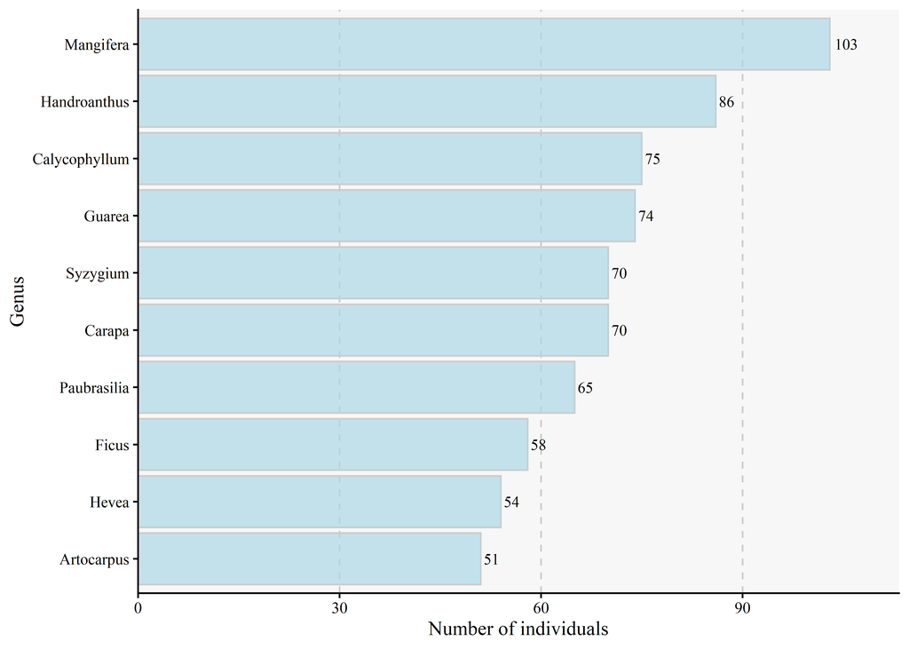

```r
# Gráfico com a frequência dos 10 gêneros mais abundantes de árvores
arvore %>%
  filter(!is.na(genus)) %>%
  count(genus) %>%
  arrange(desc(n)) %>%
  slice_head(n = 10) %>%
  ggplot(aes(x = n, y = reorder(genus, n))) +
  geom_col(fill = "lightblue", color = "grey80", alpha = 0.7) +
  geom_text(aes(label = n), hjust = -0.2, family = "serif", size = 3) +
  labs(x = "Number of individuals", y = "Genus") +
  scale_x_continuous(expand = expansion(mult = c(0, 0.1))) +
  theme_classic() +
  theme(text = element_text(family = "serif"),
        panel.grid.major.x = element_line(linetype = "dashed", color = "gray80"),
        panel.background = element_rect(fill = "grey97"))
```

## 2.2. Como está estruturada a população do arboreto em termos de altura e DAP? As palmeiras e árvores do arboreto estão concentradas em classes específicas de altura e DAP, ou apresentam distribuição ampla de tamanhos?

```r
# Definir classes de altura
arvore <- arvore %>%
    mutate(classe_alt = cut(altura, breaks = 10))
```

```r
# Calcular as frequências para cada classe de dap
classe_altura <- arvore %>%
  count(classe_alt, name = "Freq_obs") %>%
  mutate(Fre_rel = Freq_obs / sum(Freq_obs),
    Freq_acum_obs = cumsum(Freq_obs),
    Freq_acum_rel = cumsum(Fre_rel))

classe_altura<- classe_altura %>%
  bind_rows(summarise(., classe_alt = "Total",
                      Freq_obs = sum(Freq_obs),
                      Fre_rel = sum(Fre_rel),
                      Freq_acum_obs = sum(Freq_obs),
                      Freq_acum_rel = 1))

classe_altura
```

```
##     classe_alt Freq_obs      Fre_rel Freq_acum_obs Freq_acum_rel
## 1  (2.64,6.85]      297 0.1041009464           297     0.1041009
## 2    (6.85,11]      746 0.2614791448          1043     0.3655801
## 3    (11,15.2]      724 0.2537679635          1767     0.6193481
## 4  (15.2,19.3]      527 0.1847178409          2294     0.8040659
## 5  (19.3,23.5]      326 0.1142656852          2620     0.9183316
## 6  (23.5,27.7]      144 0.0504731861          2764     0.9688048
## 7  (27.7,31.8]       60 0.0210304942          2824     0.9898353
## 8    (31.8,36]       23 0.0080616894          2847     0.9978970
## 9    (36,40.2]        5 0.0017525412          2852     0.9996495
## 10 (40.2,44.4]        1 0.0003505082          2853     1.0000000
## 11       Total     2853 1.0000000000          2853     1.0000000
```

```r
# Tabela com altura média, altura mediana e altura máxima por família
arvore %>%
  group_by(family) %>%
  summarise(
    n = n(),
    altura_media = mean(altura, na.rm = TRUE),
    altura_mediana = median(altura, na.rm = TRUE),
    altura_max = max(altura, na.rm = TRUE)
  ) %>%
  arrange(desc(altura_media))
```

```
## # A tibble: 69 × 5
##    family               n altura_media altura_mediana altura_max
##    <chr>            <int>        <dbl>          <dbl>      <dbl>
##  1 Malpighiaceae        5         22.1           21.9       25.6
##  2 Rubiaceae           89         21.1           22.1       33.5
##  3 Myristicaceae       12         20.4           19.3       29
##  4 Vochysiaceae         1         20.1           20.1       20.1
##  5 Hernandiaceae        6         20.1           19.9       25.4
##  6 Burseraceae          9         18.5           16.9       36.4
##  7 Ochnaceae            3         18.5           19.6       20.9
##  8 Combretaceae        11         17.3           18.0       28.1
##  9 Pinaceae            12         17.2           16.7       23.8
## 10 Chrysobalanaceae    27         17.0           17.0       25.4
## # ℹ 59 more rows
```

```r
#TOP 20 espécies mais altas
arvore %>%
  filter(!is.na(altura)) %>%
  arrange(desc(altura)) %>%
  dplyr::select(family, genus, species, altura) %>%
  slice_head(n = 20)
```

```
##           family         genus      species altura
## 1      Meliaceae         Khaya senegalensis  44.35
## 2      Malvaceae         Ceiba    pentandra  39.63
## 3      Meliaceae         Khaya senegalensis  38.35
## 4       Fabaceae  Schizolobium     parahyba  36.46
## 5      Myrtaceae      Corymbia   citriodora  36.37
## 6    Burseraceae      Aucoumea    klaineana  36.35
## 7      Malvaceae         Ceiba    pentandra  35.97
## 8      Malvaceae         Ceiba    pentandra  35.97
## 9      Malvaceae         Ceiba    pentandra  35.59
## 10     Malvaceae         Ceiba    pentandra  35.57
## 11      Fabaceae       Samanea    inopinata  34.30
## 12     Malvaceae         Ceiba    pentandra  34.18
## 13     Myrtaceae    Eucalyptus     globulus  33.69
## 14      Fabaceae      Hymenaea oblongifolia  33.62
## 15     Meliaceae         Khaya senegalensis  33.56
## 16     Rubiaceae Calycophyllum   spruceanum  33.53
## 17     Meliaceae         Khaya         <NA>  33.48
## 18      Fabaceae        Parkia    multijuga  33.36
## 19 Lecythidaceae    Couroupita   guianensis  33.35
## 20     Rubiaceae Calycophyllum   spruceanum  33.12
```

```r
# top 10 espécies com maior altura e DAP
arvore %>%
  filter(!is.na(altura)) %>%
  arrange(desc(altura)) %>%
  slice_head(n = 10) %>%
  dplyr::select(family, genus, species, altura, dap)
```

```
##         family        genus      species altura    dap
## 1    Meliaceae        Khaya senegalensis  44.35 150.56
## 2    Malvaceae        Ceiba    pentandra  39.63 219.00
## 3    Meliaceae        Khaya senegalensis  38.35 155.97
## 4     Fabaceae Schizolobium     parahyba  36.46 119.05
## 5    Myrtaceae     Corymbia   citriodora  36.37 125.10
## 6  Burseraceae     Aucoumea    klaineana  36.35 105.36
## 7    Malvaceae        Ceiba    pentandra  35.97 142.22
## 8    Malvaceae        Ceiba    pentandra  35.97 135.79
## 9    Malvaceae        Ceiba    pentandra  35.59 159.15
## 10   Malvaceae        Ceiba    pentandra  35.57 167.24
```

```r
arvore <- arvore %>%
  mutate(classe_alt = cut(altura, breaks = 10))


classe_altura <- arvore %>%
  count(classe_alt, name = "Freq_obs") %>%
  arrange(classe_alt) %>%
  mutate(
    Fre_rel = Freq_obs / sum(Freq_obs),
    Freq_acum_obs = cumsum(Freq_obs),
    Freq_acum_rel = cumsum(Fre_rel)
  )
total <- classe_altura %>%
  summarise(
    classe_alt = "Total",
    Freq_obs = sum(Freq_obs),
    Fre_rel = sum(Fre_rel),
    Freq_acum_obs = NA,
    Freq_acum_rel = NA
  )

classe_altura_final <- bind_rows(classe_altura, total)

classe_altura_final
```

```
##     classe_alt Freq_obs      Fre_rel Freq_acum_obs Freq_acum_rel
## 1  (2.64,6.85]      297 0.1041009464           297     0.1041009
## 2    (6.85,11]      746 0.2614791448          1043     0.3655801
## 3    (11,15.2]      724 0.2537679635          1767     0.6193481
## 4  (15.2,19.3]      527 0.1847178409          2294     0.8040659
## 5  (19.3,23.5]      326 0.1142656852          2620     0.9183316
## 6  (23.5,27.7]      144 0.0504731861          2764     0.9688048
## 7  (27.7,31.8]       60 0.0210304942          2824     0.9898353
## 8    (31.8,36]       23 0.0080616894          2847     0.9978970
## 9    (36,40.2]        5 0.0017525412          2852     0.9996495
## 10 (40.2,44.4]        1 0.0003505082          2853     1.0000000
## 11       Total     2853 1.0000000000            NA            NA
```

```r
classes_altura <- c(2.64, 6.85, 11, 15.2, 19.3, 23.5, 27.7, 31.8, 36, 40.2, 44.4)
```

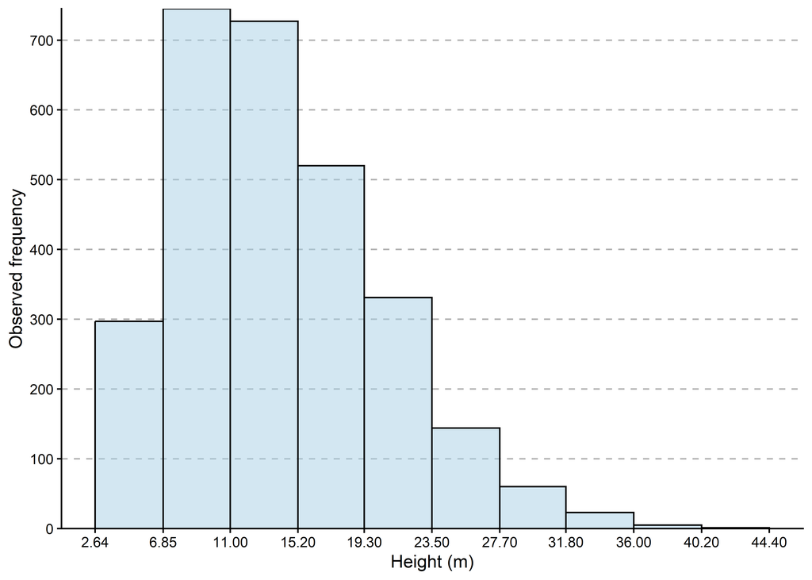

```r
# Table visualization
hist_alt <- ggplot(arvore, aes(x = altura)) +
  geom_histogram(bins = 10, fill = "#A8D0E6", color = "black", breaks = classes_altura, alpha = 0.5) +
  labs(x = "Height (m)", y = "Observed frequency") +
  scale_y_continuous(expand = c(0, 0), breaks = c(seq(0, 700, by = 100))) +
  scale_x_continuous(breaks = classes_altura) +
  theme_classic() +
  theme(
  panel.grid.major.y = element_line(
    linetype = "dashed",
    color = "grey70"
  )
)
hist_alt
```

```r
classes_dap <- c(9.98, 31.6, 53.1, 74.5, 95.9, 117, 139, 160, 182, 203, 225)
```

```r
arvore <- arvore %>%
  mutate(
    classe_dap = cut(
      dap,
      breaks = classes_dap,
      include.lowest = TRUE
    )
  )
```

```r
# Calcular as frequências para cada classe de dap
classe_dap <- arvore %>%
  count(classe_dap, name = "Freq_obs") %>%
  mutate(Fre_rel = Freq_obs / sum(Freq_obs),
    Freq_acum_obs = cumsum(Freq_obs),
    Freq_acum_rel = cumsum(Fre_rel))

classe_dap<- classe_dap %>%
  bind_rows(summarise(., classe_dap = "Total",
                      Freq_obs = sum(Freq_obs),
                      Fre_rel = sum(Fre_rel),
                      Freq_acum_obs = sum(Freq_obs),
                      Freq_acum_rel = 1))

classe_dap
```

```
##     classe_dap Freq_obs      Fre_rel Freq_acum_obs Freq_acum_rel
## 1  [9.98,31.6]     1161 0.4069400631          1161     0.4069401
## 2  (31.6,53.1]      787 0.2758499825          1948     0.6827900
## 3  (53.1,74.5]      429 0.1503680336          2377     0.8331581
## 4  (74.5,95.9]      218 0.0764107957          2595     0.9095689
## 5   (95.9,117]      135 0.0473186120          2730     0.9568875
## 6    (117,139]       63 0.0220820189          2793     0.9789695
## 7    (139,160]       40 0.0140203295          2833     0.9929898
## 8    (160,182]       16 0.0056081318          2849     0.9985980
## 9    (182,203]        2 0.0007010165          2851     0.9992990
## 10   (203,225]        2 0.0007010165          2853     1.0000000
## 11       Total     2853 1.0000000000          2853     1.0000000
```

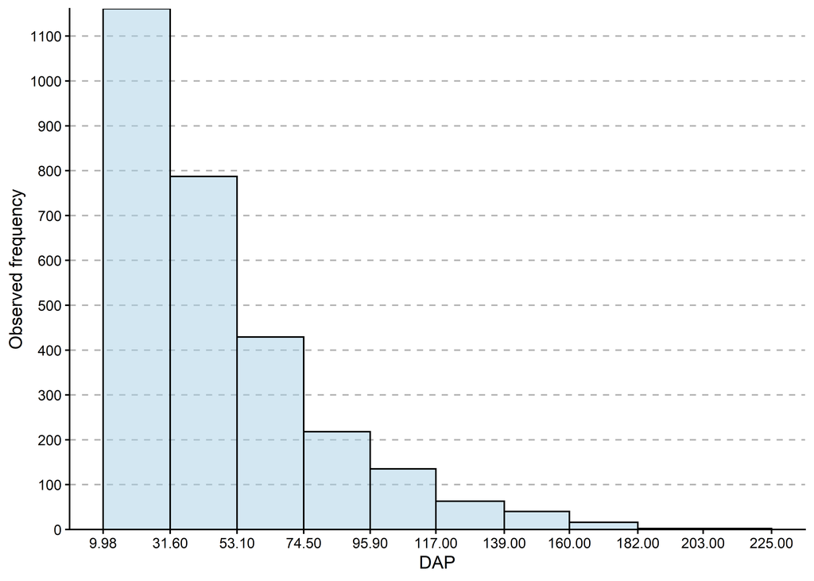

```r
# Table visualization
  hist_dap <- ggplot(arvore, aes(x = dap)) +
  geom_histogram(bins = 10, fill = "#A8D0E6", color = "black", breaks = classes_dap, alpha = 0.5) +
  labs(x = "DAP", y = "Observed frequency") +
  scale_y_continuous(expand = c(0, 0), breaks = c(seq(0, 1300, by = 100))) +
  scale_x_continuous(breaks = classes_dap) +
  theme_classic() +
  theme(
  panel.grid.major.y = element_line(
    linetype = "dashed",
    color = "grey70"
  )
)
hist_dap
```

```r
# indivíduos com dap >= 100
arvore %>%
  filter(dap >= 100) %>%
  summarise(n = n())
```

```
##     n
## 1 220
```

```r
# Famílias com DAP >= 100
tab_familias_100 <- arvore %>%
  filter(dap >= 100) %>%
  count(family, name = "n_individuos") %>%
  arrange(desc(n_individuos))

tab_familias_100
```

```
##              family n_individuos
## 1     Anacardiaceae           43
## 2          Moraceae           39
## 3          Fabaceae           38
## 4         Meliaceae           31
## 5         Malvaceae           20
## 6     Lecythidaceae           11
## 7  Chrysobalanaceae            6
## 8         Myrtaceae            6
## 9       Sapindaceae            6
## 10    Euphorbiaceae            3
## 11     Bignoniaceae            2
## 12   Calophyllaceae            2
## 13     Cupressaceae            2
## 14        Lauraceae            2
## 15      Burseraceae            1
## 16    Caryocaraceae            1
## 17        Ebenaceae            1
## 18       Lythraceae            1
## 19   Phyllanthaceae            1
## 20   Phytolaccaceae            1
## 21       Salicaceae            1
## 22    Simaroubaceae            1
## 23       Urticaceae            1
```

```r
tab_top6 <- arvore %>%
  filter(dap >= 100) %>%
  count(family, name = "n_individuos") %>%
  arrange(desc(n_individuos)) %>%
  slice_head(n = 6)

tab_top6
```

```
##          family n_individuos
## 1 Anacardiaceae           43
## 2      Moraceae           39
## 3      Fabaceae           38
## 4     Meliaceae           31
## 5     Malvaceae           20
## 6 Lecythidaceae           11
```

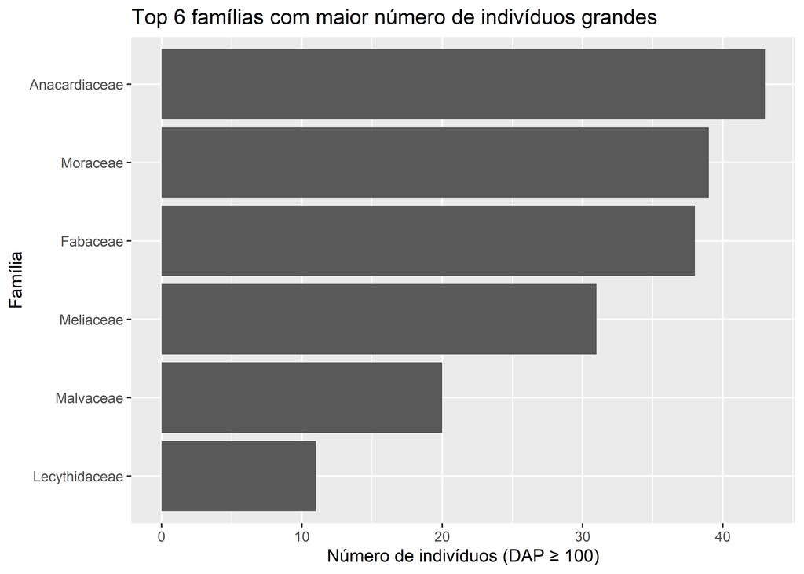

```r
ggplot(tab_top6, aes(x = reorder(family, n_individuos), y = n_individuos)) +
  geom_col() +
  coord_flip() +
  labs(
    x = "Família",
    y = "Número de indivíduos (DAP ≥ 100)",
    title = "Top 6 famílias com maior número de indivíduos grandes"
  )
```

### 🔴 Sugestão do professor:

Lembro novamente sobre a organização e identificação do código com cabeçalhos. Muitos trechos paracem ter sio copiados e colados da IA sem preocupação de organizar e identificar. Além disso, os gráficos poderiam ter sido combinados em uma única visualização. Mas para isso teríamos que alargar o tamanho da janela de figura do chunk (reparem como o excesso de leinha verticais poluiu a figura):

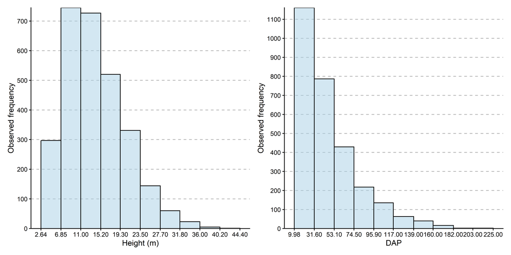

```r
# Junção dos histogramas de altura e DAP
hist_alt + hist_dap
```

## 2.3. A relação entre altura e DAP é forte entre indivíduos? O DAP é um bom preditor da altura no arboreto?

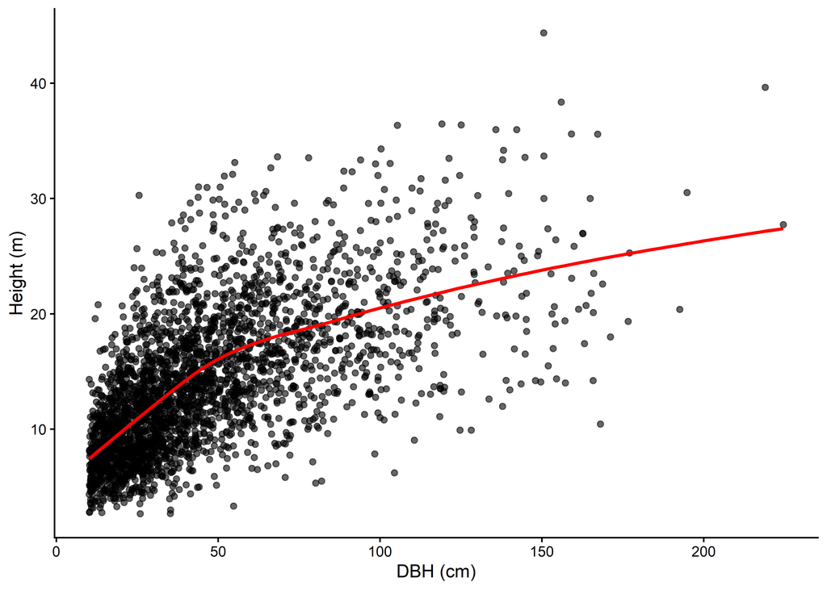

```r
alt_dap <- with(arvore, cor.test(altura, dap))
ggplot(arvore, aes(x = dap, y = altura)) +
  geom_jitter(width = 0.025, alpha = 0.6) +
  geom_smooth(method = "loess", se = F, color = "red") +
  labs(x = "DBH (cm)", y = "Height (m)") +
  theme_classic()
```

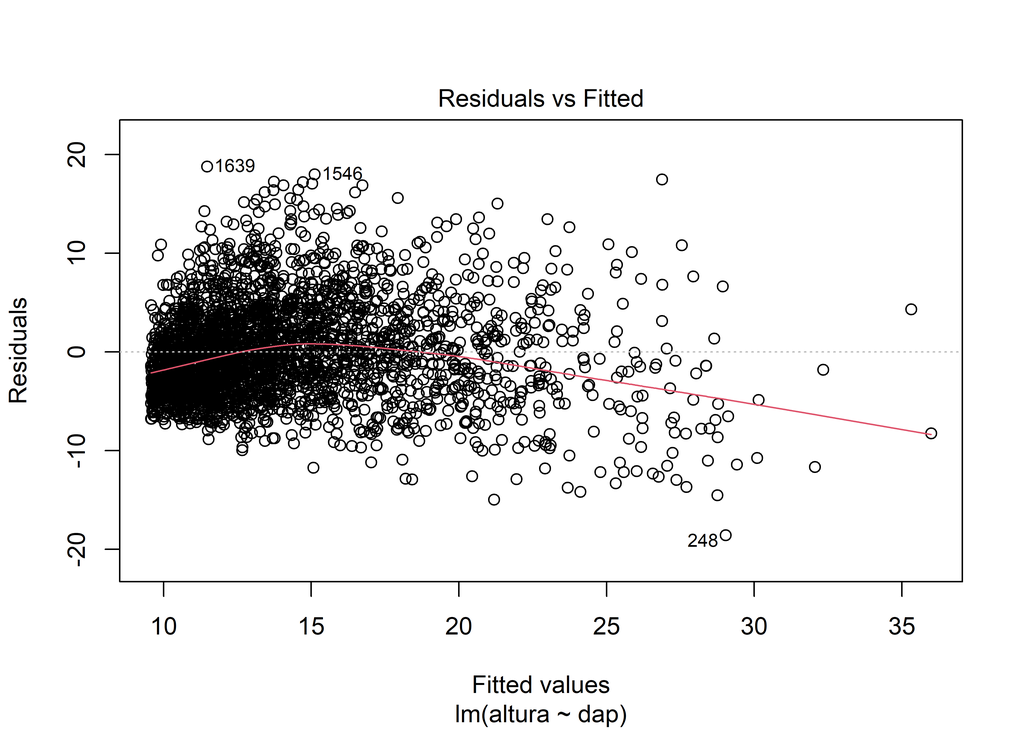

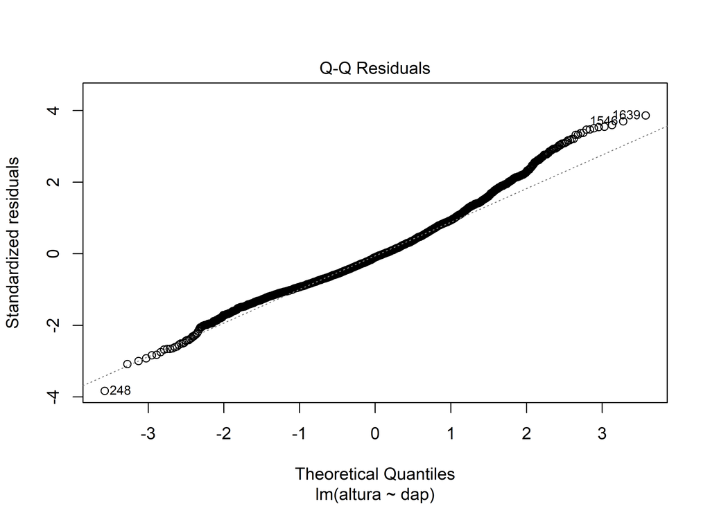

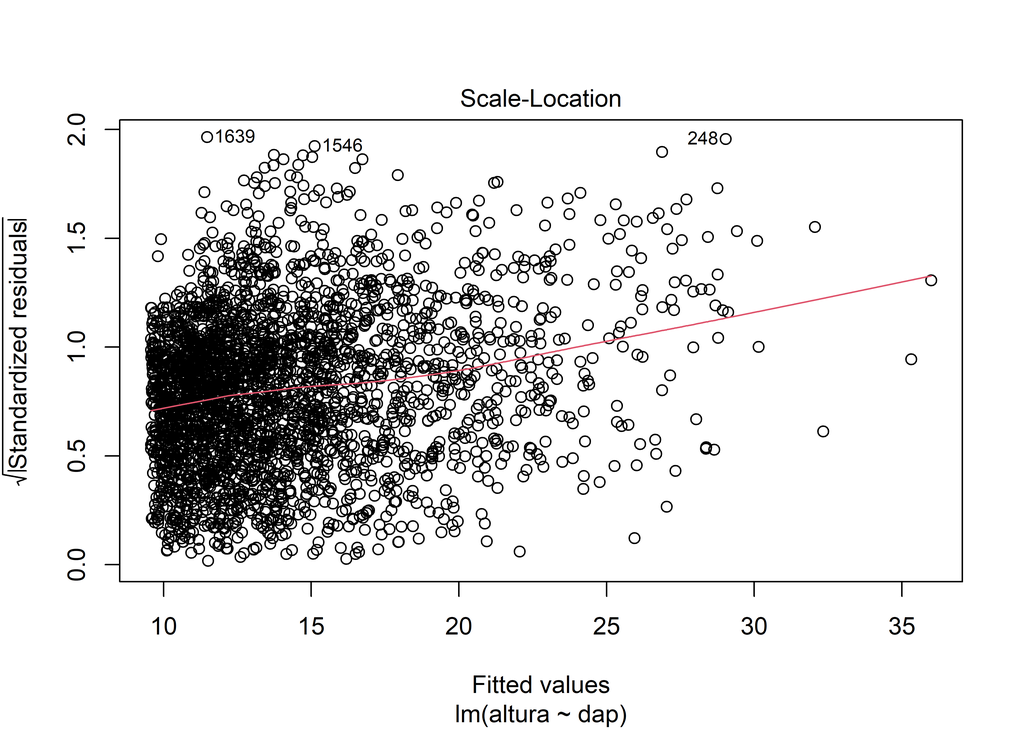

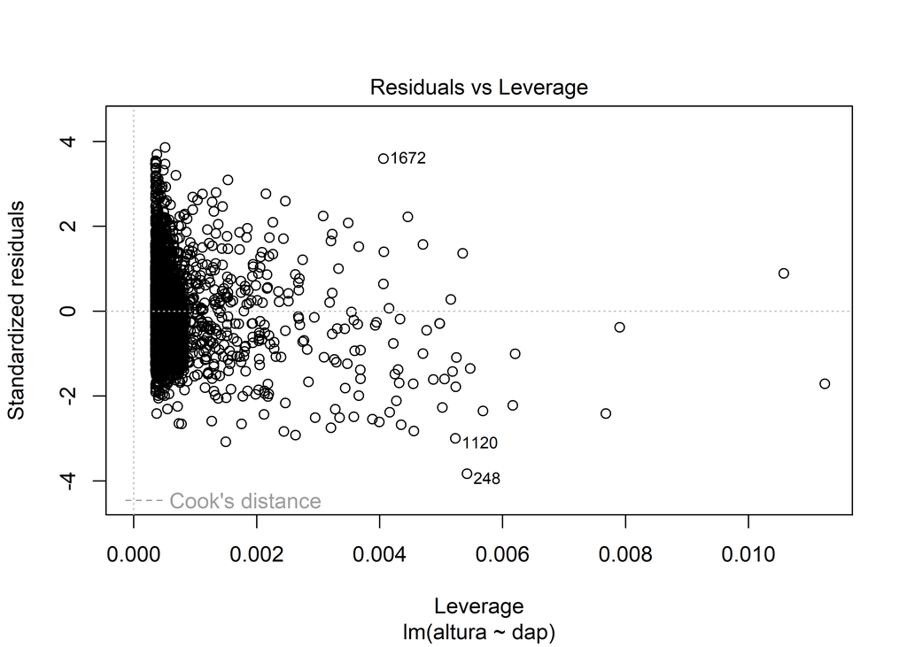

```r
modelo_altura <- lm(altura ~ dap, data = arvore)

plot(modelo_altura)
```

```r
alt_dap <- cor.test(arvore$altura, arvore$dap, method = "spearman", exact = F)
alt_dap
```

```
##
##  Spearman's rank correlation rho
##
## data:  arvore$altura and arvore$dap
## S = 1269512742, p-value < 2.2e-16
## alternative hypothesis: true rho is not equal to 0
## sample estimates:
##      rho
## 0.671993
```

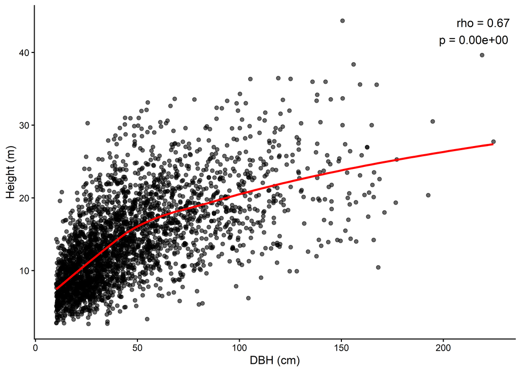

```r
alt_dap <- cor.test(arvore$altura, arvore$dap, method = "spearman")

ggplot(arvore, aes(x = dap, y = altura)) +
  geom_jitter(width = 0.025, alpha = 0.6) +
  geom_smooth(method = "loess", se = FALSE, color = "red") +
  annotate(
    "text",
    x = Inf,
    y = Inf,
    label = paste0(
      "rho = ", round(alt_dap$estimate, 2),
      "\np = ", sprintf("%.2e", alt_dap$p.value)
    ),
    hjust = 1.1,
    vjust = 1.5,
    size = 4
  ) +
  labs(x = "DBH (cm)", y = "Height (m)") +
  theme_classic()
```

### 🔴 Sugestão do professor:

O gráfico incial e final praticamente se repetem. Poderia ter mantido apenas um deles.

## 2.4. Há plantas com proporções incomuns de altura em relação ao DAP? Quais indivíduos apresentam valores extremos de relação altura/DAP, e esses indivíduos merecem atenção no monitoramento?

```r
# Dez famílias mais abundantes
top_familias <- arvore %>%
  count(family, sort = TRUE) %>%
  slice_head(n = 10)

print(top_familias)
```

```
##           family   n
## 1       Fabaceae 728
## 2      Meliaceae 210
## 3      Myrtaceae 190
## 4  Anacardiaceae 186
## 5      Malvaceae 181
## 6   Bignoniaceae 164
## 7       Moraceae 133
## 8  Lecythidaceae 113
## 9  Euphorbiaceae 103
## 10     Rubiaceae  89
```

```r
arvore <- arvore %>%
  mutate(rel_alt_dap = altura / dap)

arvore %>%
  filter(!is.na(rel_alt_dap)) %>%
  arrange(desc(rel_alt_dap)) %>%
  dplyr::select(family, genus, species, altura, dap, rel_alt_dap) %>%
  slice_head(n = 10)
```

```
##           family         genus     species altura   dap rel_alt_dap
## 1      Ochnaceae    Cespedesia  spathulata  19.59 12.03    1.628429
## 2     Clusiaceae      Garcinia gummi-gutta  20.80 12.92    1.609907
## 3    Apocynaceae  Aspidosperma  pyrifolium  14.32 10.19    1.405299
## 4      Rubiaceae Calycophyllum  spruceanum  13.91 10.76    1.292751
## 5      Rubiaceae Calycophyllum  spruceanum  16.77 13.50    1.242222
## 6      Rubiaceae Calycophyllum  spruceanum  30.27 25.56    1.184272
## 7    Apocynaceae  Aspidosperma  polyneuron  16.91 14.48    1.167818
## 8       Fabaceae         Zygia  inaequalis  13.16 11.27    1.167702
## 9       Fabaceae     Myroxylon  peruiferum  16.96 15.06    1.126162
## 10 Nyctaginaceae          Neea   madeirana  13.08 12.06    1.084577
```

```r
arvore %>%
  filter(!is.na(rel_alt_dap)) %>%
  arrange(rel_alt_dap) %>%
  dplyr::select(family, genus, species, altura, dap, rel_alt_dap) %>%
  slice_head(n = 10)
```

```
##            family      genus       species altura      dap rel_alt_dap
## 1    Cupressaceae  Cupressus      funebris   6.22 104.4100  0.05957284
## 2     Sapindaceae Dimocarpus        longan   3.34  54.7500  0.06100457
## 3        Moraceae Artocarpus heterophyllus  10.45 168.0700  0.06217647
## 4        Fabaceae       <NA>          <NA>   5.34  80.0900  0.06667499
## 5   Araucariaceae  Araucaria    columnaris   5.50  81.9000  0.06715507
## 6       Myrtaceae    Eugenia    blastantha   2.70  35.2355  0.07662726
## 7       Lauraceae Cinnamomum          <NA>   9.92 128.1432  0.07741338
## 8       Lauraceae Cinnamomum          <NA>   9.92 124.6660  0.07957264
## 9       Meliaceae     Guarea      guidonia   7.85  98.3600  0.07980887
## 10 Phyllanthaceae   Bridelia     tomentosa   9.04 110.5800  0.08175077
```

```r
Q1 <- quantile(arvore$rel_alt_dap, 0.25, na.rm = TRUE)
Q3 <- quantile(arvore$rel_alt_dap, 0.75, na.rm = TRUE)

IQR_rel <- Q3 - Q1

lim_inf <- Q1 - 1.5 * IQR_rel
lim_sup <- Q3 + 1.5 * IQR_rel

outliers <- arvore %>%
  filter(
    rel_alt_dap < lim_inf |
    rel_alt_dap > lim_sup
  ) %>%
  dplyr::select(family, genus, species, altura, dap, rel_alt_dap)

outliers
```

```
##             family         genus        species altura   dap rel_alt_dap
## 1         Fabaceae          <NA>           <NA>  18.75 22.79   0.8227293
## 2         Fabaceae        Cassia     ferruginea  11.57 11.27   1.0266193
## 3         Fabaceae  Pentaclethra      macroloba  12.91 13.78   0.9368650
## 4        Lamiaceae       Gmelina        arborea   9.51 11.14   0.8536804
## 5     Cupressaceae     Cupressus     lusitanica  20.50 23.87   0.8588186
## 6    Araucariaceae          <NA>           <NA>  10.22 12.22   0.8363339
## 7    Euphorbiaceae       Manihot carthagenensis  14.34 14.01   1.0235546
## 8     Polygonaceae     Coccoloba      latifolia  10.00 11.75   0.8510638
## 9      Sapindaceae Paranephelium   macrophyllum  11.24 11.46   0.9808028
## 10     Sapindaceae          <NA>           <NA>  12.94 14.01   0.9236260
## 11    Bignoniaceae  Handroanthus  chrysotrichus  11.22 13.46   0.8335810
## 12     Apocynaceae          <NA>           <NA>  14.54 17.19   0.8458406
## 13        Fabaceae     Myroxylon     peruiferum  16.96 15.06   1.1261620
## 14     Apocynaceae  Aspidosperma     pyricollum   9.33 11.20   0.8330357
```

[output cut: 63 more lines]

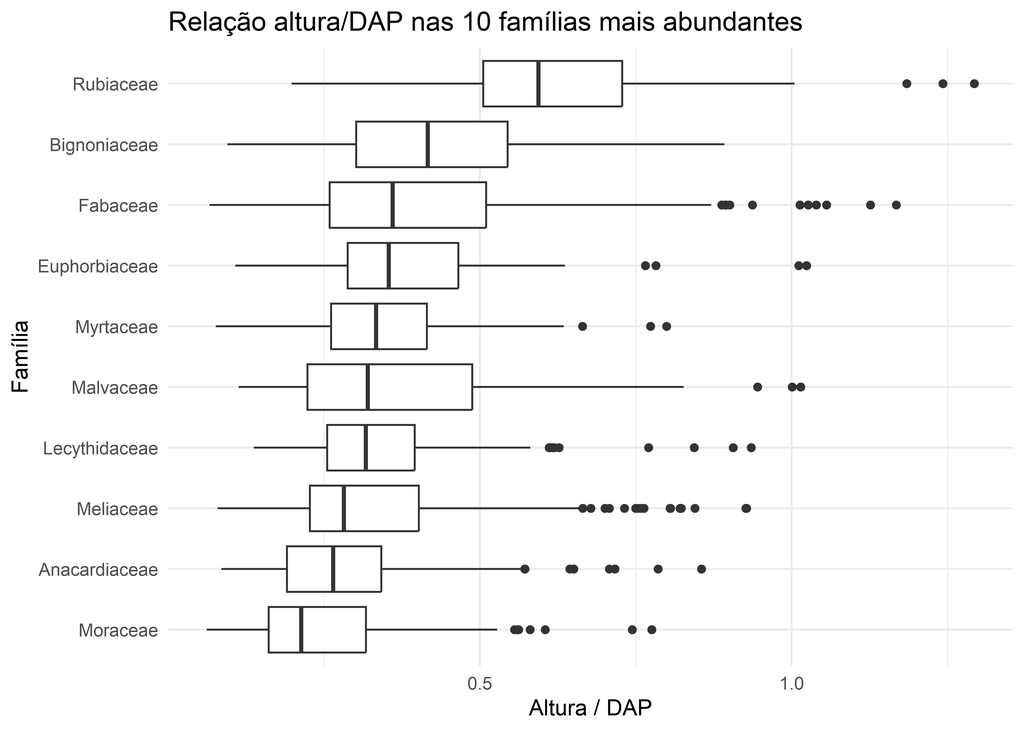

```r
familias_top <- top_familias$family

arvore %>%
  filter(family %in% familias_top,
         !is.na(rel_alt_dap)) %>%
  ggplot(aes(x = reorder(family, rel_alt_dap, median),
             y = rel_alt_dap)) +
  geom_boxplot() +
  coord_flip() +
  labs(
    title = "Relação altura/DAP nas 10 famílias mais abundantes",
    x = "Família",
    y = "Altura / DAP"
  ) +
  theme_minimal()
```

```r
Q1 <- quantile(arvore$rel_alt_dap, 0.25, na.rm = TRUE)
Q3 <- quantile(arvore$rel_alt_dap, 0.75, na.rm = TRUE)

IQR_val <- Q3 - Q1

lim_inf <- Q1 - 1.5 * IQR_val
lim_sup <- Q3 + 1.5 * IQR_val
```

```r
extremos <- arvore %>%
  filter(!is.na(rel_alt_dap)) %>%
  filter(rel_alt_dap < lim_inf | rel_alt_dap > lim_sup) %>%
  arrange(desc(rel_alt_dap)) %>%
  dplyr::select(family, genus, species, altura, dap, rel_alt_dap)
```

```r
extremos %>%
  slice_head(n = 10)
```

```
##           family         genus     species altura   dap rel_alt_dap
## 1      Ochnaceae    Cespedesia  spathulata  19.59 12.03    1.628429
## 2     Clusiaceae      Garcinia gummi-gutta  20.80 12.92    1.609907
## 3    Apocynaceae  Aspidosperma  pyrifolium  14.32 10.19    1.405299
## 4      Rubiaceae Calycophyllum  spruceanum  13.91 10.76    1.292751
## 5      Rubiaceae Calycophyllum  spruceanum  16.77 13.50    1.242222
## 6      Rubiaceae Calycophyllum  spruceanum  30.27 25.56    1.184272
## 7    Apocynaceae  Aspidosperma  polyneuron  16.91 14.48    1.167818
## 8       Fabaceae         Zygia  inaequalis  13.16 11.27    1.167702
## 9       Fabaceae     Myroxylon  peruiferum  16.96 15.06    1.126162
## 10 Nyctaginaceae          Neea   madeirana  13.08 12.06    1.084577
```

```r
extremos %>%
  arrange(rel_alt_dap) %>%
  slice_head(n = 10)
```

```
##           family         genus      species altura   dap rel_alt_dap
## 1       Fabaceae  Centrolobium   tomentosum  10.14 12.38   0.8190630
## 2      Rubiaceae Calycophyllum   spruceanum  25.33 30.91   0.8194759
## 3  Hernandiaceae     Hernandia         <NA>  16.07 19.61   0.8194799
## 4       Fabaceae       Tipuana         tipu   8.78 10.70   0.8205607
## 5      Meliaceae        Carapa   guianensis  10.45 12.73   0.8208955
## 6       Fabaceae          <NA>         <NA>  18.75 22.79   0.8227293
## 7      Meliaceae        Carapa   guianensis  10.08 12.25   0.8228571
## 8   Bignoniaceae  Handroanthus heptaphyllus   9.42 11.40   0.8263158
## 9   Polygonaceae     Triplaris         <NA>  11.00 13.31   0.8264463
## 10     Malvaceae     Sterculia      apetala  15.77 19.07   0.8269533
```

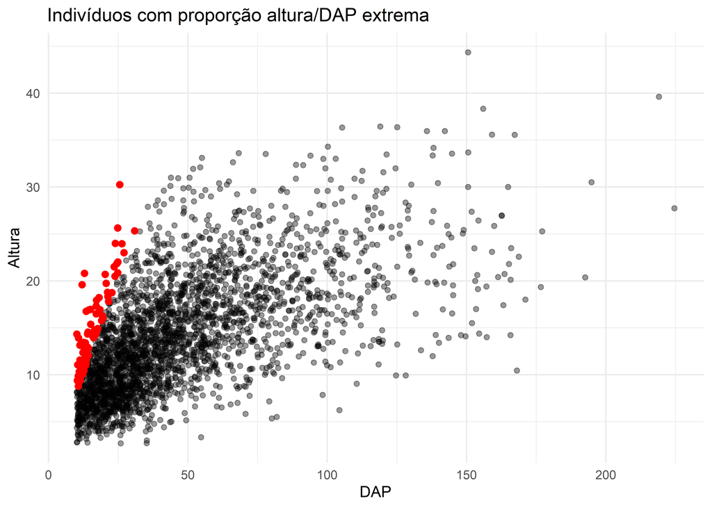

```r
ggplot(arvore, aes(x = dap, y = altura)) +
  geom_point(alpha = 0.4) +
  geom_point(data = extremos,
             aes(x = dap, y = altura),
             color = "red", size = 2) +
  theme_minimal() +
  labs(
    title = "Indivíduos com proporção altura/DAP extrema",
    x = "DAP",
    y = "Altura"
  )
```

```r
#quem são os indivíduos
extremos %>%
  mutate(individuo = paste(genus, species)) %>%
  count(individuo, sort = TRUE)
```

```
##                     individuo  n
## 1    Calycophyllum spruceanum 11
## 2                       NA NA  9
## 3           Carapa guianensis  4
## 4     Centrolobium tomentosum  3
## 5     Aspidosperma polyneuron  2
## 6       Cespedesia spathulata  2
## 7             Dalbergia nigra  2
## 8            Gustavia augusta  2
## 9   Handroanthus heptaphyllus  2
## 10                 Spachea NA  2
## 11        Theobroma speciosum  2
## 12         Amburana cearensis  1
## 13    Aspidosperma pyricollum  1
## 14    Aspidosperma pyrifolium  1
```

[output cut: 33 more lines]

```r
na_ind <- arvore %>%
  filter(
    is.na(species) |
    species == "NA" |
    str_detect(species, "NA")
  )
```

```r
na_ind %>%
  dplyr::select(family, genus, species, altura, dap) %>%
  arrange(family)
```

```
##               family           genus species altura       dap
## 1        Achariaceae     Hydnocarpus    <NA>  11.44  56.02000
## 2      Anacardiaceae        Spondias    <NA>  15.01  28.65000
## 3      Anacardiaceae            <NA>    <NA>   5.83  33.74000
## 4      Anacardiaceae            <NA>    <NA>  16.93  41.06000
## 5      Anacardiaceae        Spondias    <NA>  18.76  32.79000
## 6      Anacardiaceae        Spondias    <NA>  15.69  30.46000
## 7      Anacardiaceae      Semecarpus    <NA>  18.68  44.24000
## 8      Anacardiaceae        Spondias    <NA>  11.16  14.20000
## 9      Anacardiaceae        Spondias    <NA>  13.28  45.47123
## 10     Anacardiaceae        Spondias    <NA>  29.59 100.20000
## 11     Anacardiaceae            <NA>    <NA>   6.28  35.56357
## 12     Anacardiaceae            <NA>    <NA>   4.03  20.66000
## 13     Anacardiaceae        Spondias    <NA>   6.49  12.83000
## 14     Anacardiaceae        Spondias    <NA>  22.11  65.25000
```

[output cut: 336 more lines]

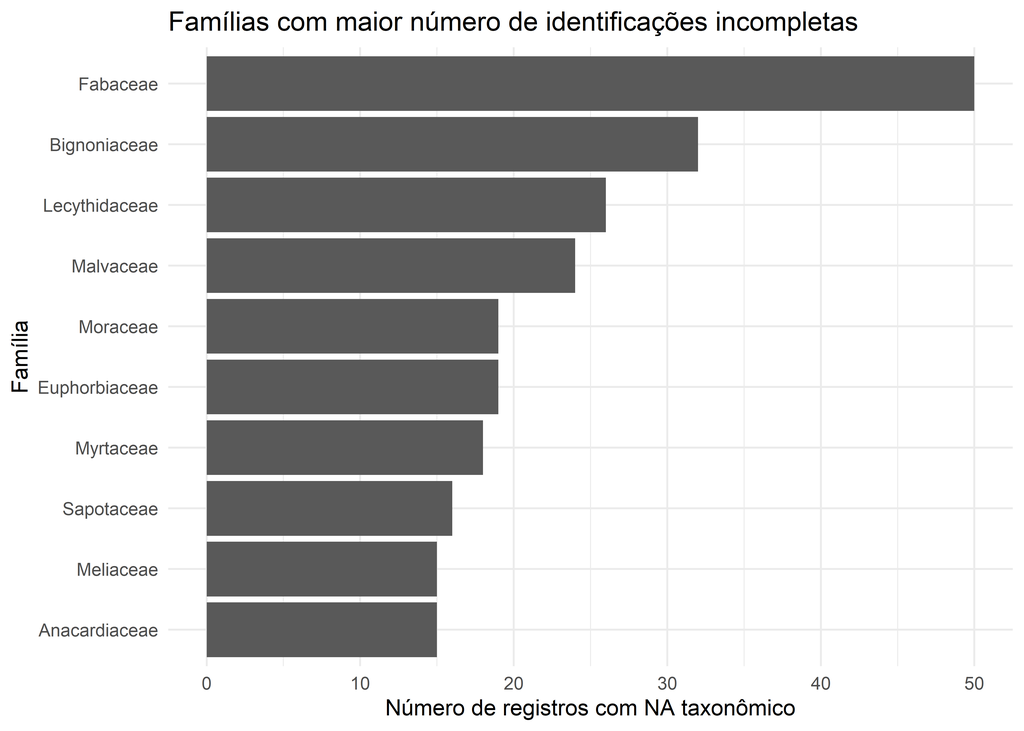

```r
na_ind <- arvore %>%
  filter(
    is.na(genus) | is.na(species) |
    str_detect(genus, "NA") |
    str_detect(species, "NA")
  )

na_familias <- na_ind %>%
  count(family, sort = TRUE) %>%
  slice_head(n = 10)

ggplot(na_familias,
       aes(x = reorder(family, n), y = n)) +
  geom_col() +
  coord_flip() +
  labs(
    title = "Famílias com maior número de identificações incompletas",
    x = "Família",
    y = "Número de registros com NA taxonômico"
  ) +
  theme_minimal()
```

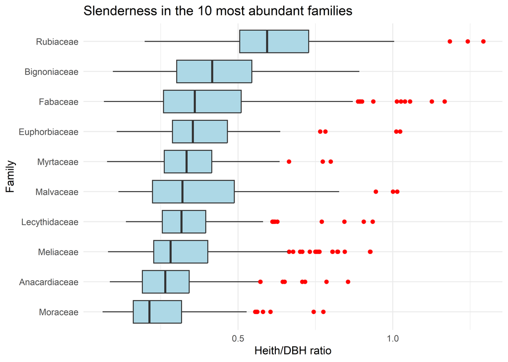

```r
#das 10 mais
arvore_top <- arvore %>%
  filter(family %in% top_familias$family)

ggplot(arvore_top, aes(x = reorder(family, rel_hd, FUN = median), y = rel_hd)) +
  geom_boxplot(outlier.color = "red", fill = "lightblue") +
  coord_flip() +   # nomes das famílias legíveis
  labs(title = "Slenderness in the 10 most abundant families",
       x = "Family", y = "Heith/DBH ratio") +
  theme_minimal()
```

```r
# identificar o outliers
# Obter os valores considerados outliers pela regra do boxplot
out_values <- boxplot.stats(arvore$rel_hd)$out

# Filtrar o dataframe para esses indivíduos
extremos <- arvore %>%
  filter(rel_hd %in% out_values) %>%
  arrange(desc(rel_hd))

# Visualizar a tabela
extremos
```

```
##    sec_cant tombo          family         genus        species
## 1       21B  4525       Ochnaceae    Cespedesia     spathulata
## 2       24A  4950      Clusiaceae      Garcinia    gummi-gutta
## 3       11E  2720     Apocynaceae  Aspidosperma     pyrifolium
## 4       25A  5004       Rubiaceae Calycophyllum     spruceanum
## 5       20C  4138       Rubiaceae Calycophyllum     spruceanum
## 6       26E  5251       Rubiaceae Calycophyllum     spruceanum
## 7       11E  2707     Apocynaceae  Aspidosperma     polyneuron
## 8       26E  5203        Fabaceae         Zygia     inaequalis
## 9       11B  2613        Fabaceae     Myroxylon     peruiferum
## 10      37A  7313   Nyctaginaceae          Neea      madeirana
## 11      32D  6624        Fabaceae  Centrolobium     tomentosum
## 12      37A  7323        Rutaceae      Clausena       excavata
## 13      20F  4250        Fabaceae  Centrolobium     tomentosum
## 14      31C  5940   Malpighiaceae       Spachea           <NA>
```

[output cut: 297 more lines]

```r
# os que estão acima do limite superior do boxplot.
lim_sup <- boxplot.stats(arvore$rel_hd)$stats[5]  # limite superior do whisker
extremos_sup <- extremos %>% filter(rel_hd > lim_sup)
```

```r
extremos_sup
```

```
##    sec_cant tombo          family         genus        species
## 1       21B  4525       Ochnaceae    Cespedesia     spathulata
## 2       24A  4950      Clusiaceae      Garcinia    gummi-gutta
## 3       11E  2720     Apocynaceae  Aspidosperma     pyrifolium
## 4       25A  5004       Rubiaceae Calycophyllum     spruceanum
## 5       20C  4138       Rubiaceae Calycophyllum     spruceanum
## 6       26E  5251       Rubiaceae Calycophyllum     spruceanum
## 7       11E  2707     Apocynaceae  Aspidosperma     polyneuron
## 8       26E  5203        Fabaceae         Zygia     inaequalis
## 9       11B  2613        Fabaceae     Myroxylon     peruiferum
## 10      37A  7313   Nyctaginaceae          Neea      madeirana
## 11      32D  6624        Fabaceae  Centrolobium     tomentosum
## 12      37A  7323        Rutaceae      Clausena       excavata
## 13      20F  4250        Fabaceae  Centrolobium     tomentosum
## 14      31C  5940   Malpighiaceae       Spachea           <NA>
```

[output cut: 297 more lines]

```r
# Extatísticas do boxplot
bp <- boxplot.stats(arvore$rel_hd)

length(bp$out)
```

```
## [1] 77
```

```r
# menores valores de rel_hd
n_menores <- 10

menores <- arvore %>%
  arrange(rel_hd) %>%
  slice_head(n = n_menores)
```

```r
menores
```

```
##    sec_cant tombo         family      genus       species
## 1       13D  6143   Cupressaceae  Cupressus      funebris
## 2        6C  1593    Sapindaceae Dimocarpus        longan
## 3        5N  1431       Moraceae Artocarpus heterophyllus
## 4       34C  6980       Fabaceae       <NA>          <NA>
## 5        6D  1683  Araucariaceae  Araucaria    columnaris
## 6        8C  2025      Myrtaceae    Eugenia    blastantha
## 7       26F  8214      Lauraceae Cinnamomum          <NA>
## 8       26F  8215      Lauraceae Cinnamomum          <NA>
## 9       26E  5211      Meliaceae     Guarea      guidonia
## 10      30B  5561 Phyllanthaceae   Bridelia     tomentosa
##                        name habito_pad altura      dap densidade n_caule
## 1        Cupressus funebris       Tree   6.22 104.4100      0.47       1
## 2         Dimocarpus longan       Tree   3.34  54.7500      0.70       1
## 3  Artocarpus heterophyllus       Tree  10.45 168.0700      0.53       1
```

[output cut: 29 more lines]

### 🔴 Sugestão do professor:

Aqui o principal problema foi o excesso e repetição de processos e códigos. Alguns códigos me parecem desnecessários para responder a pergunta. Também, a solicitação foi compilar o Markdown dos dois subgrupos e não copiar e colar tudo que os dois fizeram.

## 2.5. As famílias ou gêneros mais abundantes são também as dominantes? Avaliem quais concentram os maiores valores de altura e área basal

```r
#tabela com média e desvio de padrão por família
#repetição a nível de família
family_freq <- arvore %>%
  group_by(family) %>%
  reframe(
    freq = n(),
    dom = sum(area_basal)
  ) %>%
  arrange(desc(freq))

family_freq
```

```
## # A tibble: 69 × 3
##    family         freq   dom
##    <chr>         <int> <dbl>
##  1 Fabaceae        728 159.
##  2 Meliaceae       210  84.7
##  3 Myrtaceae       190  25.9
##  4 Anacardiaceae   186  86.1
##  5 Malvaceae       181  58.8
##  6 Bignoniaceae    164  18.1
##  7 Moraceae        133  87.4
##  8 Lecythidaceae   113  35.7
##  9 Euphorbiaceae   103  22.4
## 10 Rubiaceae        89  11.8
## # ℹ 59 more rows
```

```r
family_freq <- arvore %>%
  group_by(family) %>%
  reframe(freq = n())
```

```r
graf_freq <- family_freq %>%
  slice_max(freq, n = 20) %>%
  ggplot(aes(x = reorder(family, freq), y = freq)) +
  geom_col(fill = "gray50") +
  coord_flip() +
  scale_y_continuous(
    breaks = seq(0, max(family_freq$freq), by = 100)
  ) +
  labs(
    x = "Family",
    y = "Frequency"
  ) +
  theme_classic()
```

```r
family_dom <- arvore %>%
  group_by(family) %>%
  reframe(
    dom = sum(area_basal)
  )
```

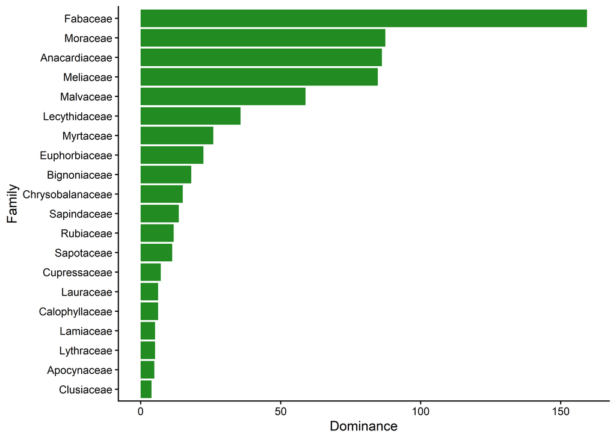

```r
graf_dom <- family_dom %>%
  slice_max(dom, n = 20) %>%
  ggplot(aes(x = reorder(family, dom), y = dom)) +
  geom_col(fill = "forestgreen") +
  coord_flip() +
  scale_y_continuous(
    breaks = seq(0, max(family_dom$dom), by = 50)
  ) +
  labs(
    x = "Family",
    y = "Dominance"
  ) +
  theme_classic()
graf_dom
```

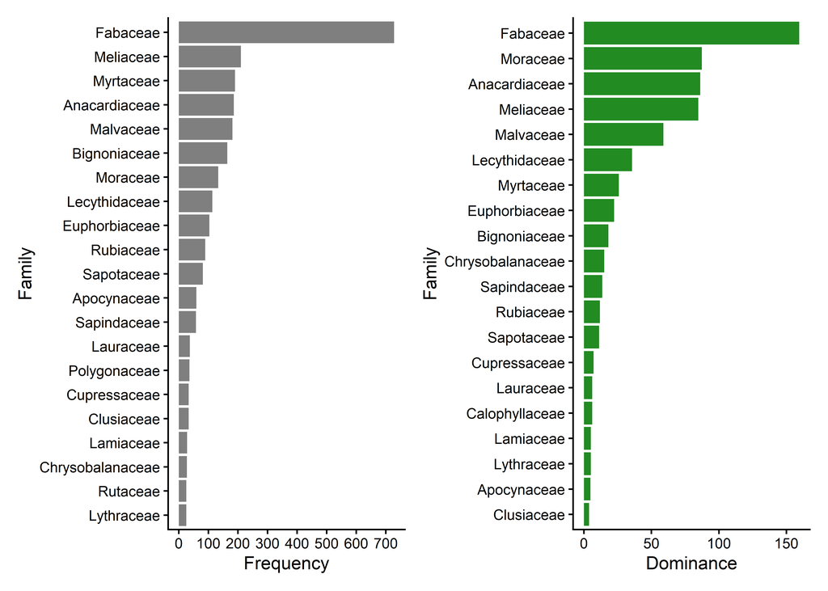

```r
graf_freq + graf_dom
```

```r
freq_dom <- family_freq %>%
  left_join(family_dom, by = "family")
```

```r
cor_teste <- cor.test(
  freq_dom$freq,
  freq_dom$dom,
  method = "spearman",
  exact = FALSE
)

cor_teste
```

```
##
##  Spearman's rank correlation rho
##
## data:  freq_dom$freq and freq_dom$dom
## S = 3221.7, p-value < 2.2e-16
## alternative hypothesis: true rho is not equal to 0
## sample estimates:
##       rho
## 0.9411449
```

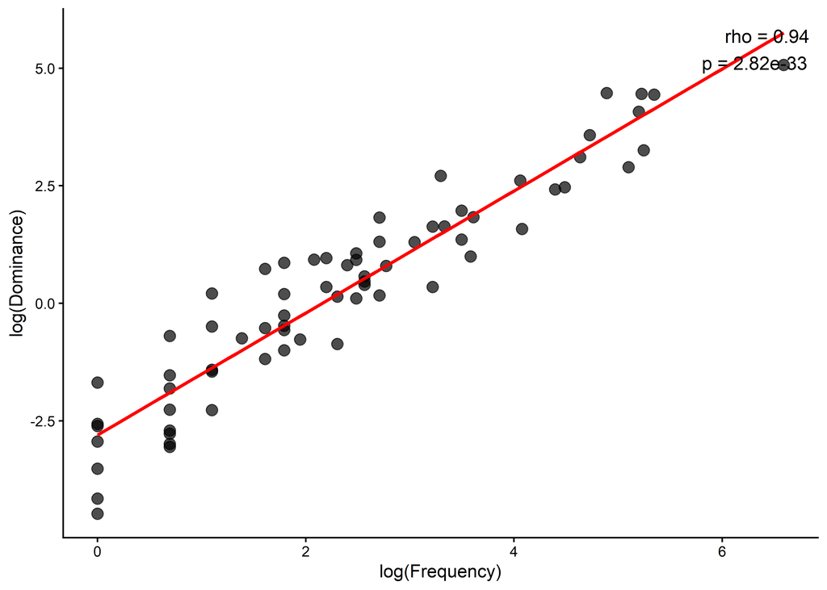

```r
ggplot(freq_dom, aes(x = log(freq), y = log(dom))) +
  geom_point(size = 3, alpha = 0.7) +
  geom_smooth(method = "lm", se = FALSE, color = "red") +
  annotate(
    "text",
    x = Inf,
    y = Inf,
    label = paste0(
      "rho = ", round(cor_teste$estimate, 2),
      "\np = ", sprintf("%.2e", cor_teste$p.value)
    ),
    hjust = 1.1,
    vjust = 1.5,
    size = 4
  ) +
  labs(
    x = "log(Frequency)",
    y = "log(Dominance)"
  ) +
  theme_classic()
```

### 🔴 Sugestão do professor

Uma sugestão para aprimorar a visualização seria identificar as famílias no gráfico. Vejam:

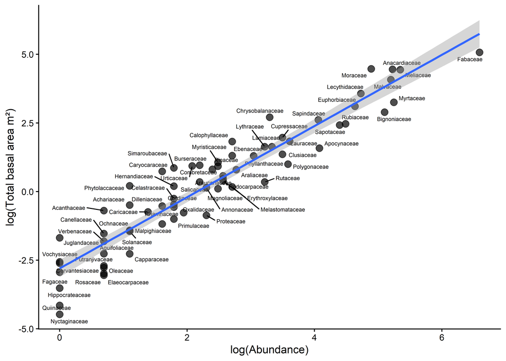

```r
# Gráfico de dispersão entre a abundância dos gêneros e sua área basal total.
ggplot(freq_dom, aes(x = log(freq), y = log(dom))) +
  geom_point(size = 3, alpha = 0.7) +
  geom_text_repel(aes(label = family), size = 2, max.overlaps = Inf) +
  geom_smooth(method = "lm", se = TRUE) +
  labs(x = "log(Abundance)", y = "log(Total basal area m²)") +
  theme_classic()
```

Acho que, para discutir essa questão no artigo, podemos utilizar outro tipo de gráfico: o *bump chart*. Sei que não abordamos esse tipo de visualização em aula, ele não me ocorreu naquele momento, apenas depois. Mas vejam abaixo como o gráfico fica mais informativo:

```r
# Summary table for trees
tab_res_arv <- arvore %>%
  filter(!is.na(family)) %>%
  group_by(family) %>%
  summarise(n = n(), altura_media = mean(altura), altura_max = max(altura), area_basal_total = sum(area_basal), area_basal_media = mean(area_basal)) %>%
  arrange(desc(area_basal_total))

tab_res_arv
```

```
## # A tibble: 69 × 6
##    family            n altura_media altura_max area_basal_total area_basal_media
##    <chr>         <int>        <dbl>      <dbl>            <dbl>            <dbl>
##  1 Fabaceae        728         14.5       36.5            159.             0.219
##  2 Moraceae        133         15.9       27.5             87.4            0.657
##  3 Anacardiaceae   186         14.2       29.6             86.1            0.463
##  4 Meliaceae       210         17.0       44.4             84.7            0.403
##  5 Malvaceae       181         14.8       39.6             58.8            0.325
##  6 Lecythidaceae   113         16.5       33.4             35.7            0.316
##  7 Myrtaceae       190         10.4       36.4             25.9            0.136
##  8 Euphorbiaceae   103         16.2       30.4             22.4            0.218
##  9 Bignoniaceae    164         11.8       30.4             18.1            0.110
## 10 Chrysobalana…    27         17.0       25.4             15.0            0.556
## # ℹ 59 more rows
```

```r
# Ranking abundance and total basal area
rank_arv <- tab_res_arv %>%
  filter(n >= 10) %>%
  mutate(rank_abundancia = rank(-n, ties.method = "first"), rank_area_basal = rank(-area_basal_total, ties.method = "first"))

rank_arv
```

```
## # A tibble: 35 × 8
##    family            n altura_media altura_max area_basal_total area_basal_media
##    <chr>         <int>        <dbl>      <dbl>            <dbl>            <dbl>
##  1 Fabaceae        728         14.5       36.5            159.             0.219
##  2 Moraceae        133         15.9       27.5             87.4            0.657
##  3 Anacardiaceae   186         14.2       29.6             86.1            0.463
##  4 Meliaceae       210         17.0       44.4             84.7            0.403
##  5 Malvaceae       181         14.8       39.6             58.8            0.325
##  6 Lecythidaceae   113         16.5       33.4             35.7            0.316
##  7 Myrtaceae       190         10.4       36.4             25.9            0.136
##  8 Euphorbiaceae   103         16.2       30.4             22.4            0.218
##  9 Bignoniaceae    164         11.8       30.4             18.1            0.110
## 10 Chrysobalana…    27         17.0       25.4             15.0            0.556
## # ℹ 25 more rows
## # ℹ 2 more variables: rank_abundancia <int>, rank_area_basal <int>
```

```r
# Converting table to long format
rank_arv_long <- rank_arv %>%
  dplyr::select(family, rank_abundancia, rank_area_basal) %>%
  pivot_longer(cols = c(rank_abundancia, rank_area_basal), names_to = "variavel", values_to = "ranking") %>%
  mutate(variavel = dplyr::recode(variavel, rank_abundancia = "Abundance", rank_area_basal = "Total basal area"),
    variavel = factor(variavel, levels = c("Abundance", "Total basal area")))

rank_arv_long
```

```
## # A tibble: 70 × 3
##    family        variavel         ranking
##    <chr>         <fct>              <int>
##  1 Fabaceae      Abundance              1
##  2 Fabaceae      Total basal area       1
##  3 Moraceae      Abundance              7
##  4 Moraceae      Total basal area       2
##  5 Anacardiaceae Abundance              4
##  6 Anacardiaceae Total basal area       3
##  7 Meliaceae     Abundance              2
##  8 Meliaceae     Total basal area       4
##  9 Malvaceae     Abundance              5
## 10 Malvaceae     Total basal area       5
## # ℹ 60 more rows
```

```r
# Setting color palette
familias <- sort(unique(rank_arv_long$family))

cores_familias <- colorRampPalette(RColorBrewer::brewer.pal(8, "Dark2"))(length(familias))

names(cores_familias) <- familias
```

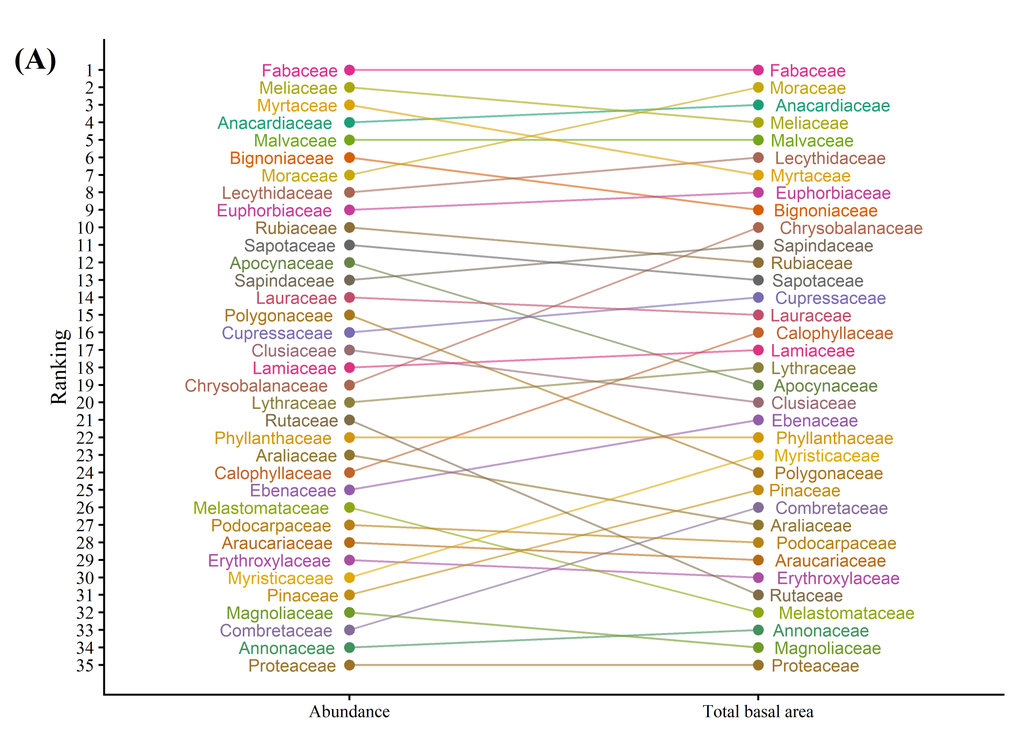

```r
# Visualizing
bump_arv <-
ggplot(rank_arv_long, aes(x = variavel, y = ranking, group = family, color = family)) +
  geom_line(alpha = 0.6) +
  geom_point(size = 2) +
  geom_text(data = rank_arv_long %>% filter(variavel == "Abundance"), aes(label = family), hjust = 1.15, size = 3) +
  geom_text(data = rank_arv_long %>% filter(variavel == "Total basal area"), aes(label = family), hjust = -0.15, size = 3) +
  scale_y_reverse(breaks = seq(1, max(rank_arv_long$ranking), by = 1)) +
  scale_color_manual(values = cores_familias) +
  coord_cartesian(clip = "off") +
  labs(x = NULL, y = "Ranking", title = "(A)") +
  theme_classic() +
  theme(text = element_text(family = "serif"),
        legend.position = "none",
        plot.title = element_text(hjust = -0.04, vjust = -6, face = "bold", size = 15),
        plot.title.position = "plot",
        plot.margin = margin(1, 10, 5, 25))

bump_arv
```

## 2.6. Avaliem a altura dominante em canteiros com mais de 10 plantas

```r
alturas_dominantes <- arvore %>%
  group_by(sec_cant) %>%
  mutate(n_plantas = n()) %>%
  filter(n_plantas > 10) %>%
  group_by(sec_cant) %>%
  slice_max(altura, n = 1, with_ties = FALSE) %>%
  ungroup() %>%
  arrange(desc(altura))
alturas_dominantes
```

```
## # A tibble: 95 × 19
##    sec_cant tombo family   genus species name  habito_pad altura   dap densidade
##    <chr>    <int> <chr>    <chr> <chr>   <chr> <chr>       <dbl> <dbl>     <dbl>
##  1 27C       5311 Meliace… Khaya senega… Khay… Tree         44.4  151.      0.52
##  2 8A        1917 Malvace… Ceiba pentan… Ceib… Tree         39.6  219       0.25
##  3 28B       6185 Meliace… Khaya senega… Khay… Tree         38.4  156.      0.52
##  4 20G       4287 Myrtace… Cory… citrio… Cory… Tree         36.4  125.      0.83
##  5 30G       5794 Malvace… Ceiba pentan… Ceib… Tree         36.0  142.      0.25
##  6 27D       5368 Malvace… Ceiba pentan… Ceib… Tree         35.6  159.      0.25
##  7 20C       4135 Malvace… Ceiba pentan… Ceib… Tree         35.6  167.      0.25
##  8 14A       3049 Fabaceae Sama… inopin… Sama… Tree         34.3  100.      0.55
##  9 18A       3740 Myrtace… Euca… globul… Euca… Tree         33.7  151.      0.8
## 10 28C       6207 Meliace… Khaya <NA>    <NA>  Tree         33.5  121.      0.62
## # ℹ 85 more rows
## # ℹ 9 more variables: n_caule <int>, multicaule <int>, multicaule_l <chr>,
## #   rel_hd <dbl>, area_basal <dbl>, classe_alt <fct>, classe_dap <fct>,
## #   rel_alt_dap <dbl>, n_plantas <int>
```

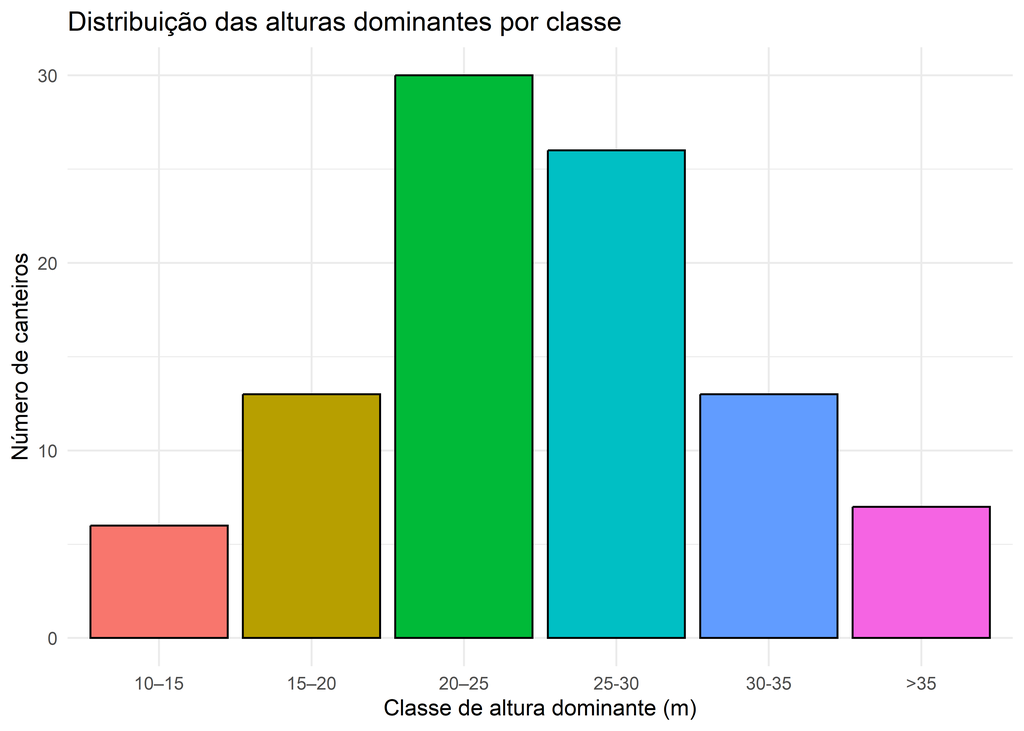

```r
# Criar classes de altura
alturas_dominantes <- alturas_dominantes %>%
  mutate(classe_alt = cut(altura,
                          breaks = c(0, 10, 15, 20, 25, 30, 35, 50),  # intervalos em metros
                          labels = c("≤10", "10–15", "15–20", "20–25", "25-30", "30-35", ">35"),
                          include.lowest = TRUE))

# Contar canteiros por classe
dist_classe <- alturas_dominantes %>%
  count(classe_alt)

# Gráfico de barras da frequência
ggplot(dist_classe, aes(x = classe_alt, y = n, fill = classe_alt)) +
  geom_col(color = "black") +
  labs(title = "Distribuição das alturas dominantes por classe",
       x = "Classe de altura dominante (m)", y = "Número de canteiros") +
  theme_minimal() +
  theme(legend.position = "none")
```

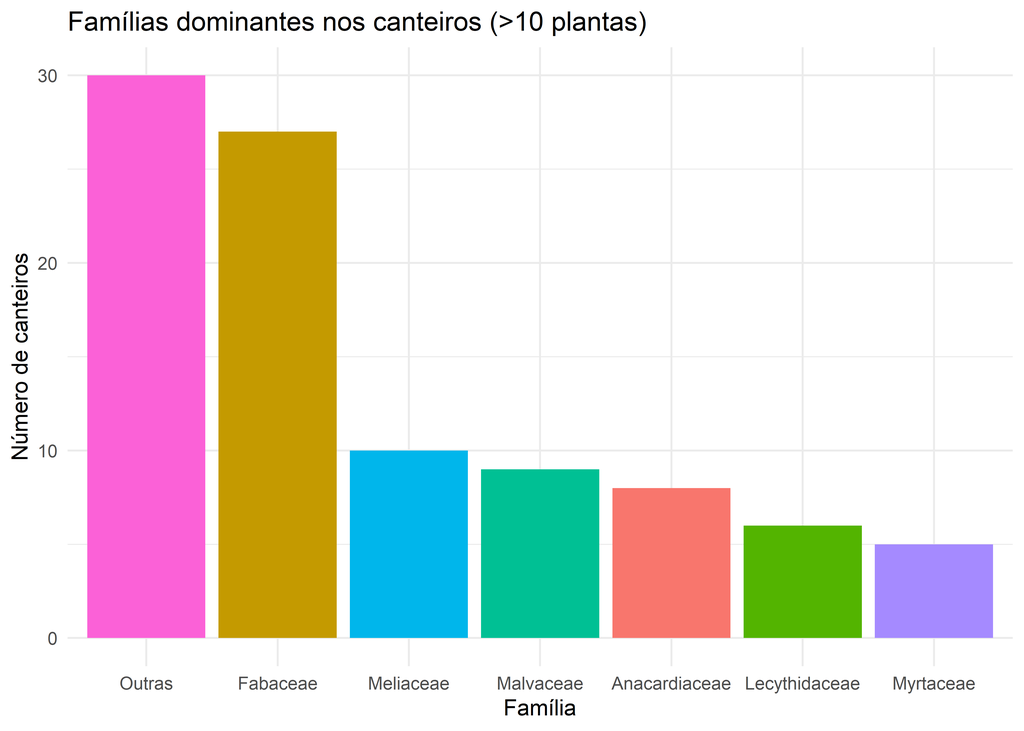

```r
#por famílias mais frequentes
# Contagem das famílias dominantes
top_fam_dom <- alturas_dominantes %>%
  count(family, sort = TRUE) %>%
  mutate(family_agrup = ifelse(row_number() <= 6, family, "Outras"))  # top 6 + outras

# Juntar de volta ao dataframe
alturas_dominantes <- alturas_dominantes %>%
  left_join(top_fam_dom %>% dplyr::select(family, family_agrup), by = "family")

# Gráfico: quantos canteiros têm dominância de cada família (agrupada)
ggplot(alturas_dominantes, aes(x = fct_infreq(family_agrup), fill = family_agrup)) +
  geom_bar() +
  labs(title = "Famílias dominantes nos canteiros (>10 plantas)",
       x = "Família", y = "Número de canteiros") +
  theme_minimal() +
  theme(legend.position = "none")
```

```r
class(top_fam_dom)
```

```
## [1] "tbl_df"     "tbl"        "data.frame"
```

```r
head(top_fam_dom)
```

```
## # A tibble: 6 × 3
##   family            n family_agrup
##   <chr>         <int> <chr>
## 1 Fabaceae         27 Fabaceae
## 2 Meliaceae        10 Meliaceae
## 3 Malvaceae         9 Malvaceae
## 4 Anacardiaceae     8 Anacardiaceae
## 5 Lecythidaceae     6 Lecythidaceae
## 6 Myrtaceae         5 Myrtaceae
```

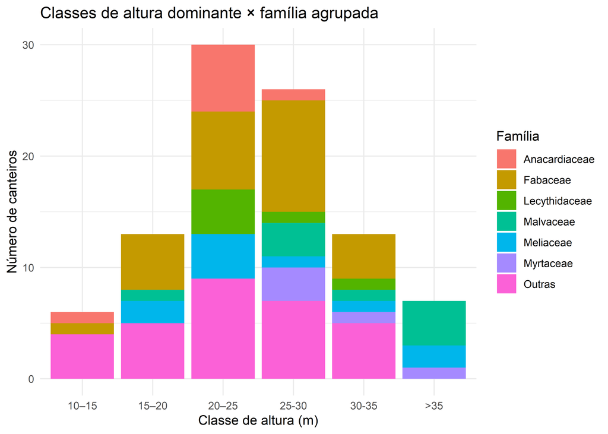

```r
ggplot(alturas_dominantes, aes(x = classe_alt, fill = family_agrup)) +
  geom_bar() +
  labs(title = "Classes de altura dominante × família agrupada",
       x = "Classe de altura (m)", y = "Número de canteiros", fill = "Família") +
  theme_minimal()
```